# Nelson Lab Hw 2

Paul Cho

2025-09-04

# 1. Use the ‘setup.Rmd’ file to create the folders that you will use for the analysis of this dataset.

### Loading packages first

Run install.packages (“here”) in the console

```r
library(Seurat)
library(dplyr)
library(here)
here()
```

```
## [1] "/Users/paulcho/Desktop/R projects/Nelson Hw 2"
```

### 1.1 Music selection

[Pat Metheny Group - Pat Metheny Group](https://open.spotify.com/album/4TC69U5HGclykFldzvsIao?si=WRLgAvpWSEO2S4D1JIc_lQ)

### Making folders

Using concatenate to make a list of folder names, then storing it in object “dirs”(directories). Folder names & functionalities were recommended by chat

```r
# - data/cellranger: where barcodes.tsv.gz, features.tsv.gz, matrix.mtx.gz (Q2) will go
# - outputs: where you'll later save the Seurat object .rds (Q3f)
# - results/figures, results/tables: plots and tabular outputs
# - qc, logs, docs, scripts: supporting work
dirs <- c(
  "data/raw",
  "data/cellranger",   # for barcodes.tsv.gz, features.tsv.gz, matrix.mtx.gz
  "data/processed",
  "scripts",
  "results/figures",
  "results/tables",
  "outputs",           # folder to save .rds files
  "qc",
  "logs",
  "docs"
)
```

## 1a. Knit the file and add documentation that you created the folders.

Creating folders

```r
full_paths <- file.path(here(), dirs)
created <- logical(length(full_paths))

for (i in seq_along(full_paths)) {
  if (!dir.exists(full_paths[i])) {
    dir.create(full_paths[i], recursive = TRUE, showWarnings = FALSE)
    created[i] <- TRUE
  } else {
    created[i] <- FALSE
  }
}
```

Making sure the code prints as a log

```r
creation_log <- data.frame(
  directory = dirs,
  path      = full_paths,
  status    = ifelse(created, "created", "already existed"),
  row.names = NULL
)
creation_log
```

```
##          directory
## 1         data/raw
## 2  data/cellranger
## 3   data/processed
## 4          scripts
## 5  results/figures
## 6   results/tables
## 7          outputs
## 8               qc
## 9             logs
## 10            docs
##                                                             path
## 1         /Users/paulcho/Desktop/R projects/Nelson Hw 2/data/raw
## 2  /Users/paulcho/Desktop/R projects/Nelson Hw 2/data/cellranger
## 3   /Users/paulcho/Desktop/R projects/Nelson Hw 2/data/processed
```

[output cut: 18 more lines]

I’m assuming the “already existed” part is because I already ran the script?

# 2. Move the Cell Ranger Output files (barcodes.tsv.gz, features.tsv.gz, matrix.mtx.gz) into the new folder.

Not sure whether I’m being asked to move them into cellranger with code? or just dragging & dropping them .. chat helped make template for this chunk:

```r
source_dir <- "~/Desktop/R projects/Nelson Hw 2/Homework Dataset"
destination_dir <- here::here("data", "cellranger")

files_to_move <- c("barcodes.tsv.gz", "features.tsv.gz", "matrix.mtx.gz")

# Loop and move
for (f in files_to_move) {
  file.copy(from = file.path(source_dir, f),
            to   = file.path(destination_dir, f),
            overwrite = TRUE)
}
```

## 2a. Use the package here() to upload the dataset so it sets a relative file length to upload the file.

### Building path to cellranger folder

```r
data_dir <- here("data", "cellranger")

list.files(data_dir)
```

```
## [1] "barcodes.tsv.gz" "features.tsv.gz" "matrix.mtx.gz"
```

```r
kidney.data <- Read10X(data.dir = data_dir)
```

Wrap into a Seurat object

```r
kidney <- CreateSeuratObject(counts = kidney.data, project = "Kidney")
kidney
```

```
## An object of class Seurat
## 32285 features across 11830 samples within 1 assay
## Active assay: RNA (32285 features, 0 variable features)
##  1 layer present: counts
```

# 3) Analyze the shotgun kidney snRNAseq dataset.

Quality control using seurat

```r
cells_before <- ncol(kidney)
kidney[["percent.mt"]] <- PercentageFeatureSet(kidney, pattern = "^mt-")
head(kidney@meta.data)
```

```
##                    orig.ident nCount_RNA nFeature_RNA percent.mt
## AAACCCAAGTCCGCGT-1     Kidney       2435         1476  8.0082136
## AAACCCACAAGAAATC-1     Kidney       6854         2649  0.1750802
## AAACCCACAGCTGTTA-1     Kidney       6269         2622  0.3349817
## AAACCCACATATGGCT-1     Kidney       1438          921  0.6258693
## AAACCCACATGACTCA-1     Kidney       2736         1447  0.5482456
## AAACCCAGTAAGATTG-1     Kidney       5829         2451  0.1715560
```

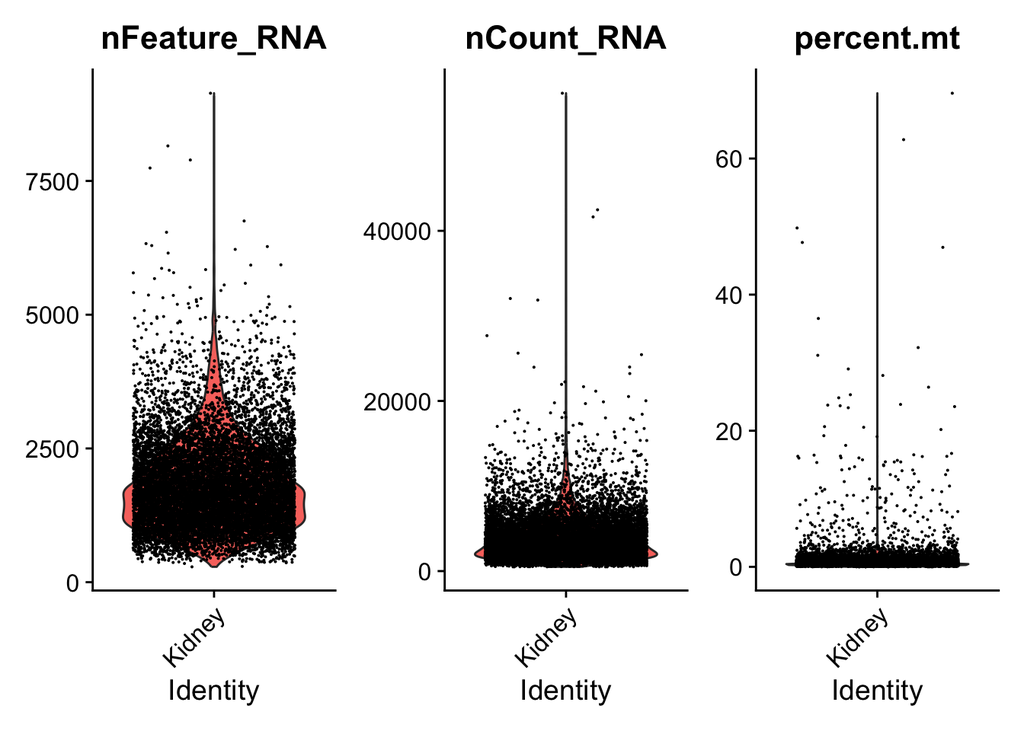

```r
VlnPlot(kidney, features = c("nFeature_RNA", "nCount_RNA", "percent.mt"), ncol = 3)
```

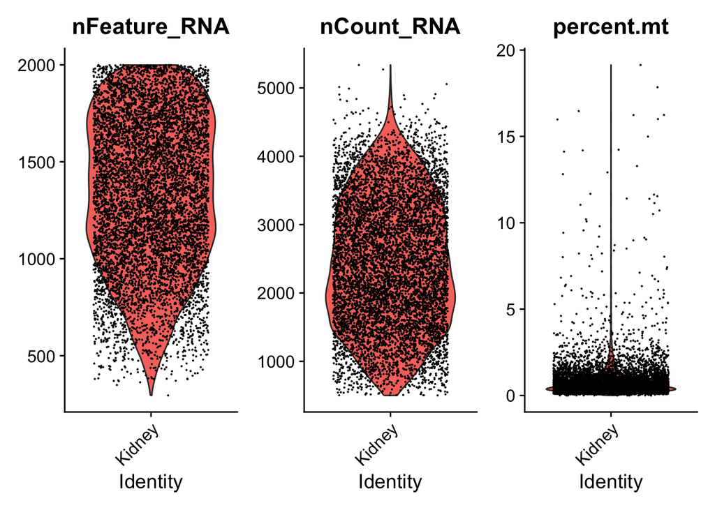

```r
kidney <- subset(kidney, subset = nFeature_RNA < 2000 & nFeature_RNA < 4000 & percent.mt < 20)
cells_after <-ncol(kidney)
cells_removed <- cells_before - cells_after
VlnPlot(kidney, features = c("nFeature_RNA", "nCount_RNA", "percent.mt"), ncol = 3)
```

```r
kidney <- NormalizeData(kidney, normalization.method = "LogNormalize", scale.factor = 10000)
```

```
## Normalizing layer: counts
```

```r
kidney <- FindVariableFeatures(kidney, selection.method = "vst", nfeatures = 2000)
```

```
## Finding variable features for layer counts
```

cells_before and cells_after were created for 3ii

### ii. How many cells do they filter out?

Using concatenate to print the number of cells filtered out:

```r
c(cells_before = cells_before,
  cells_after  = cells_after,
  cells_removed = cells_removed)
```

```
##  cells_before   cells_after cells_removed
##         11830          7616          4214
```